# **HOMEWORK 1 (124 points + 1) : CAUTION! CONTENTS ARE HOT**

## **DUE: *FEBRUARY 19, 2026 @ 11:59 PM***

## **24-HR LATE DUE DATE WITH A 15% PENALTY: *FEBRUARY 20, 2026 @ 11:59 PM***

[figure not shown]

**We are going to dive straight into these volcanoes (well... their dataset), to swim our way into Pandas proficiency!**

You will find the [Pandas Documentation](https://pandas.pydata.org/docs/user_guide/index.html) helpful. There are also some helpful links to guide you along the way! Don't get burned

# **For this assignment, we are including a special bonus question to help everyone get familiar with the proper assignment submission routine. We strongly encourage you to complete Bonus Question 1, learn the process, and follow this practice for all future assignments.**

# **For this assignment only, you will not lose points if you skip the bonus question. However, starting from Homework 2, submitting both the Jupyter Notebook file and the PDF will be required in order to receive full credit.**

### **DO NOT REMOVE ANY PART OF ANY OF THE QUESTIONS OR YOU LOSE CREDIT**

### **REMEMBER TO SHOW OUTPUT**

### **Part 1: Maintenance (25 POINTS TOTAL)**

First, we're going to familiarize ourselves with the process. As in most languages, Python looks best when its modules are imported first before any other code is written

```python
# Make sure these code blocks run properly and that you have properly installed the appropriate modules required.
import pandas as pd
import requests
# import other libraries here

# Don't Remove this
pd.set_option('display.max_rows', None)
pd.set_option('display.max_columns', None)
```

As you may have noticed, there's another library aside from Pandas called "[requests](https://requests.readthedocs.io/en/latest/)." **The requests library allows you to send HTTP requests to a server, retrieve the content, and process it at ease.** It's very beginner friendly for those attempting to get into webscraping (super important for collecting and creating datasets). We also recommend looking into [BeautifulSoup](https://beautiful-soup-4.readthedocs.io/en/latest/) (yeah, soup LOL), another wonderful library that can be paired with the requests library for webscraping.

As shown below, sometimes specific websites require specific headers in order to process a request to access the data.

To check if a request was processed successfully, use the [status_code](https://requests.readthedocs.io/en/latest/api/) function to see if the process returned 200.

```python
# Make sure these code blocks run properly and that you have properly installed the appropriate modules required.
import pandas as pd
import requests
# import other libraries here

# Don't Remove this
pd.set_option('display.max_rows', None)
pd.set_option('display.max_columns', None)

# API URL and headers in case request gets denied.
api_url = "https://www.ngdc.noaa.gov/hazel/hazard-service/api/v1/volcanoes"

headers = {
    'accept': '*/*'
}

req = requests.request('GET', api_url, headers=headers)
print(req.status_code)
```

```
200
```

#### **TASK 1.0: Cute Webscraping (5 points)**

To make our cute webscraper we need to **create a GET request** using the relevant information given above.

This particular dataset NOAA returns data from the API as **json** when a user makes a request. The json data has a particular format, so we will extract our needed information only from the field called **items** to make a dataframe.

**After properly scraping the data, name this dataframe** **df**

**Save this dataframe into a CSV file named 'volcanoes.csv'**

**You won't need to run this more than once**

```python
# importing required libraries
import pandas as pd
import requests

api_url = "https://www.ngdc.noaa.gov/hazel/hazard-service/api/v1/volcanoes"


req = requests.request('GET', api_url)
tmp = req.json().get("items")
print(tmp)

df = pd.DataFrame(tmp)
df.to_csv("volcanoes.csv")
```

```
[{'id': 1, 'year': 1169, 'month': 2, 'day': 4, 'tsunamiEventId': 2852, 'earthquakeEventId': 421, 'volcanoLocationId': 10106, 'volcanoLocationNewNum': 211060, 'volcanoLocationNum': '0101-06=', 'name': 'Etna', 'location': 'Italy', 'country': 'Italy', 'latitude': 37.748, 'longitude': 14.999, 'elevation…
```

#### **TASK 1.1: 1 Liner Thingz (3 points)**

We need to get an idea of what this dataset is going to look. In order to do that, let's take a look at some of the most [basic things](https://www.dataquest.io/cheat-sheet/pandas-cheat-sheet/) our dataframe has.

**Read the directions carefully and code your answer with only one line of code.**

**CAN'T USE LOOPS. DO NOT DISPLAY THE DATAFRAME, JUST YOUR CODE OUTPUT HERE.**

**1.1.1:** In one line of code and **using only one single method call**, output the **summary statistics** (count, mean, std, min, max, quartiles) of all numerical features in the dataframe.

*Hint: Look for a method that gives a descriptive overview of numerical columns.*

```python
df.describe()
```

|  | id | year | month | day | tsunamiEventId | earthquakeEventId | volcanoLocationId | volcanoLocationNewNum | latitude | longitude | elevation | deathsTotal | deathsAmountOrderTotal | damageAmountOrderTotal | vei | deathsAmountOrder | damageAmountOrder | housesDestroyedAmountOrderTotal | deaths | injuries | injuriesAmountOrder | injuriesTotal | injuriesAmountOrderTotal | housesDestroyedAmountOrder | housesDestroyed | housesDestroyedTotal | missingAmountOrder | missingAmountOrderTotal | missing | … |
| --- | --- | --- | --- | --- | --- | --- | --- | --- | --- | --- | --- | --- | --- | --- | --- | --- | --- | --- | --- | --- | --- | --- | --- | --- | --- | --- | --- | --- | --- | --- |
| count | 200.000000 | 200.000000 | 177.000000 | 155.000000 | 37.000000 | 17.000000 | 200.000000 | 200.000000 | 200.000000 | 200.000000 | 200.000000 | 128.000000 | 180.000000 | 59.000000 | 192.000000 | 169.000000 | 51.000000 | 52.000000 | 118.000000 | 30.000000 | 39.000000 | 33.000000 | 41.000000 | 42.000000 | 13.000000 | 16.000000 | 3.0 | 3.0 | 1.0 | … |
| mean | 375.635000 | 1809.800000 | 6.293785 | 15.825806 | 1818.648649 | 3632.117647 | 57207.110000 | 258519.715000 | 5.852440 | 103.641705 | 1835.110000 | 1028.007812 | 1.677778 | 2.084746 | 2.692708 | 1.609467 | 1.823529 | 2.403846 | 429.483051 | 90.400000 | 1.589744 | 113.060606 | 1.682927 | 2.309524 | 1102.000000 | 1326.312500 | 2.0 | 2.0 | 78.0 | … |
| std | 306.114755 | 248.034282 | 3.469611 | 9.185073 | 1742.563313 | 3015.859162 | 24461.022227 | 20706.407256 | 18.170994 | 48.350940 | 1032.617325 | 5692.045543 | 1.039207 | 0.952096 | 0.956843 | 0.994703 | 0.931791 | 0.995275 | 1513.433735 | 210.136507 | 0.849704 | 227.506310 | 0.878608 | 1.047368 | 2451.426863 | 2568.800543 | 1.0 | 1.0 | NaN | … |
| min | 1.000000 | -141.000000 | 1.000000 | 1.000000 | 61.000000 | 421.000000 | 10101.000000 | 211010.000000 | -38.157000 | -175.630000 | -5.000000 | 1.000000 | 1.000000 | 1.000000 | 0.000000 | 1.000000 | 1.000000 | 1.000000 | 1.000000 | 1.000000 | 1.000000 | 1.000000 | 1.000000 | 1.000000 | 10.000000 | 10.000000 | 1.0 | 1.0 | 78.0 | … |
| 25% | 78.500000 | 1774.500000 | 3.000000 | 8.000000 | 613.000000 | 1328.000000 | 60325.000000 | 263250.000000 | -7.935000 | 111.847000 | 1117.000000 | 3.000000 | 1.000000 | 1.000000 | 2.000000 | 1.000000 | 1.000000 | 1.750000 | 3.000000 | 5.250000 | 1.000000 | 6.000000 | 1.000000 | 1.000000 | 50.000000 | 68.750000 | 1.5 | 1.5 | 78.0 | … |
| 50% | 348.000000 | 1880.500000 | 7.000000 | 15.000000 | 1181.000000 | 2179.000000 | 60403.000000 | 264015.000000 | 0.320000 | 121.299500 | 1714.000000 | 18.000000 | 1.000000 | 2.000000 | 3.000000 | 1.000000 | 2.000000 | 3.000000 | 13.500000 | 21.500000 | 1.000000 | 26.000000 | 1.000000 | 2.500000 | 144.000000 | 215.500000 | 2.0 | 2.0 | 78.0 | … |
| 75% | 664.250000 | 1950.000000 | 9.000000 | 24.000000 | 1977.000000 | 6195.000000 | 60807.000000 | 268070.000000 | 14.011000 | 127.332000 | 2805.000000 | 104.250000 | 2.000000 | 3.000000 | 3.000000 | 2.000000 | 3.000000 | 3.000000 | 78.500000 | 54.500000 | 2.000000 | 86.000000 | 2.000000 | 3.000000 | 800.000000 | 877.250000 | 2.5 | 2.5 | 78.0 | … |
| max | 994.000000 | 1996.000000 | 12.000000 | 31.000000 | 5863.000000 | 10519.000000 | 201141.000000 | 282110.000000 | 40.827000 | 177.180000 | 3657.000000 | 60000.000000 | 4.000000 | 4.000000 | 7.000000 | 4.000000 | 4.000000 | 4.000000 | 11000.000000 | 1000.000000 | 4.000000 | 1000.000000 | 4.000000 | 4.000000 | 9000.000000 | 9000.000000 | 3.0 | 3.0 | 78.0 | … |

**1.1.2:** In one line of code and **using only one single method call**, print the **summary information** of the dataframe, including index dtype, column names, non-null counts, and memory usage.

```python
df.info()
```

```
<class 'pandas.core.frame.DataFrame'>
RangeIndex: 200 entries, 0 to 199
Data columns (total 43 columns):
 #   Column                           Non-Null Count  Dtype
---  ------                           --------------  -----
 0   id                               200 non-null    int64
 1   year                             200 non-null    int64
 2   month                            177 non-null    float64
 3   day                              155 non-null    float64
 4   tsunamiEventId                   37 non-null     float64
 5   earthquakeEventId                17 non-null     float64
 6   volcanoLocationId                200 non-null    int64
 7   volcanoLocationNewNum            200 non-null    int64
 8   volcanoLocationNum               200 non-null    object
 9   name                             200 non-null    object
```

[output cut: 35 more lines]

We won't be using some of the data because there is a lot of missing data.

**1.1.3:** *In one line of code, create a **new dataframe** called **new_df** that **discards** all the features of the **old** dataframe **except for the following**:*

`id, year, month, day, tsunamiEventId, earthquakeEventId, volcanoLocationId, volcanoLocationNewNum, name, country, elevation, morphology, deathsTotal, vei, deaths`

*Hint: Don't use any drop function*

```python
new_df = df[["id", "year", "month", "tsunamiEventId", "earthquakeEventId", "volcanoLocationId", "volcanoLocationNewNum", "name", "country", "elevation", "morphology", "deathsTotal", "vei", "deaths"]]
```

#### **TASK 1.2: 1 Liner Shenaniganz (7 points)**

We're going to tidy up the **new dataframe** a little more with some more advanced 1 liner code.

**Read the directions carefully and code your answer with only one line of code.**

**For this section, keep the method of display that is already in the box. Write your code as indicated.**

**YOU CAN'T USE ONE LINE LOOPS OR ANY KIND OF LOOP.**

**1.2.1:** *In one line of code, **drop any row** that contains **NaN** in **any one** of the columns indicating a measure of **time**.*

```python
df.dropna(subset=["year", "month", "day"])
```

|  | id | year | month | day | tsunamiEventId | earthquakeEventId | volcanoLocationId | volcanoLocationNewNum | volcanoLocationNum | name | location | country | latitude | longitude | elevation | morphology | agent | deathsTotal | deathsAmountOrderTotal | damageAmountOrderTotal | significant | publish | eruption | status | timeErupt | vei | deathsAmountOrder | damageAmountOrder | housesDestroyedAmountOrderTotal | … |
| --- | --- | --- | --- | --- | --- | --- | --- | --- | --- | --- | --- | --- | --- | --- | --- | --- | --- | --- | --- | --- | --- | --- | --- | --- | --- | --- | --- | --- | --- | --- |
| 0 | 1 | 1169 | 2.0 | 4.0 | 2852.0 | 421.0 | 10106 | 211060 | 0101-06= | Etna | Italy | Italy | 37.748 | 14.999 | 3357 | Stratovolcano | S,W | 16000.0 | 4.0 | 4.0 | True | False | True | Historical | D1 | NaN | NaN | NaN | NaN | … |
| 1 | 2 | 1329 | 7.0 | 15.0 | NaN | NaN | 10106 | 211060 | 0101-06= | Etna | Italy | Italy | 37.748 | 14.999 | 3357 | Stratovolcano | I | NaN | 3.0 | NaN | True | False | True | Historical | D1 | 3.0 | 3.0 | NaN | NaN | … |
| 3 | 4 | 1888 | 3.0 | 13.0 | 1175.0 | NaN | 50107 | 251070 | 0501-07= | Ritter Island | New Guinea-NE of | Papua New Guinea | -5.519 | 148.115 | 75 | Stratovolcano | W | NaN | 4.0 | 3.0 | True | False | True | Historical | D1 | 2.0 | NaN | NaN | 3.0 | … |
| 5 | 6 | 1832 | 11.0 | 1.0 | NaN | NaN | 10106 | 211060 | 0101-06= | Etna | Italy | Italy | 37.748 | 14.999 | 3357 | Stratovolcano | L | NaN | 2.0 | NaN | True | False | True | Historical | D1 | 2.0 | 2.0 | NaN | NaN | … |
| 6 | 7 | 1977 | 1.0 | 10.0 | NaN | NaN | 20303 | 223030 | 0203-03= | Nyiragongo | Africa-C | Congo, DRC | -1.520 | 29.250 | 3470 | Stratovolcano | L | NaN | 2.0 | 3.0 | True | False | True | Historical | D1 | 1.0 | 2.0 | 3.0 | NaN | … |
| 8 | 9 | 1779 | 8.0 | 8.0 | NaN | NaN | 10102 | 211020 | 0101-02= | Vesuvius | Italy | Italy | 40.821 | 14.426 | 1281 | Complex volcano | NaN | NaN | 1.0 | NaN | True | False | True | Historical | D2 | 3.0 | 1.0 | NaN | NaN | … |
| 10 | 11 | 1907 | 8.0 | 4.0 | NaN | NaN | 201112 | 221112 | 0201-112 | Alayta | Africa-NE | Ethiopia | 12.888 | 40.573 | 1496 | Shield volcano | NaN | NaN | 1.0 | NaN | True | False | True | Historical | D2 | 2.0 | 1.0 | NaN | NaN | … |
| 11 | 12 | 1905 | 3.0 | 10.0 | NaN | NaN | 10102 | 211020 | 0101-02= | Vesuvius | Italy | Italy | 40.821 | 14.426 | 1281 | Complex volcano | T | 1.0 | 1.0 | NaN | True | False | True | Historical | D2 | 2.0 | 1.0 | NaN | NaN | … |
| 12 | 13 | 1986 | 7.0 | 24.0 | NaN | NaN | 10104 | 211040 | 0101-04= | Stromboli | Italy | Italy | 38.789 | 15.213 | 924 | Stratovolcano | T | 1.0 | 1.0 | NaN | True | False | True | Historical | D1 | 2.0 | 1.0 | NaN | NaN | … |
| 13 | 14 | 1536 | 3.0 | 26.0 | NaN | NaN | 10106 | 211060 | 0101-06= | Etna | Italy | Italy | 37.748 | 14.999 | 3357 | Stratovolcano | T | 1.0 | 1.0 | NaN | True | False | True | Historical | D1 | 3.0 | 1.0 | NaN | NaN | … |
| 14 | 15 | 1904 | 2.0 | 25.0 | NaN | NaN | 30301 | 233010 | 0303-01= | Karthala | Indian O-W | Comoros | -11.750 | 43.380 | 2361 | Shield volcano | L | 1.0 | 1.0 | 1.0 | True | False | True | Historical | D1 | 2.0 | 1.0 | 1.0 | NaN | … |
| 15 | 16 | 1878 | 2.0 | 4.0 | 1095.0 | 6195.0 | 50214 | 252140 | 0502-14= | Rabaul | New Britain-SW Pac | Papua New Guinea | -4.246 | 152.194 | 688 | Pyroclastic shield | T | 1.0 | 1.0 | NaN | True | False | True | Historical | D1 | 3.0 | 1.0 | NaN | NaN | … |
| 16 | 17 | 1737 | 5.0 | 20.0 | NaN | NaN | 10102 | 211020 | 0101-02= | Vesuvius | Italy | Italy | 40.821 | 14.426 | 1281 | Complex volcano | T | 2.0 | 1.0 | 2.0 | True | False | True | Historical | D2 | 3.0 | 1.0 | 2.0 | NaN | … |
| 17 | 18 | 1917 | 4.0 | 1.0 | NaN | NaN | 40105 | 241050 | 0401-05= | Okataina | New Zealand | New Zealand | -38.157 | 176.507 | 1111 | Lava dome | T | 2.0 | 1.0 | NaN | True | False | True | Historical | D1 | 1.0 | 1.0 | NaN | NaN | … |
| 19 | 20 | 1979 | 3.0 | 8.0 | NaN | NaN | 50103 | 251030 | 0501-03= | Karkar | New Guinea-NE of | Papua New Guinea | -4.647 | 145.976 | 1839 | Stratovolcano | P | 2.0 | 1.0 | NaN | True | False | True | Historical | D1 | 2.0 | 1.0 | NaN | NaN | … |
| 20 | 21 | 1970 | 3.0 | 2.0 | NaN | NaN | 10101 | 211010 | 0101-01= | Campi Flegrei | Italy | Italy | 40.827 | 14.139 | 458 | Caldera | S | 3.0 | 1.0 | 1.0 | True | False | False | Historical | D5 | NaN | 1.0 | 1.0 | 1.0 | … |
| 22 | 23 | 1682 | 8.0 | 12.0 | NaN | NaN | 10102 | 211020 | 0101-02= | Vesuvius | Italy | Italy | 40.821 | 14.426 | 1281 | Complex volcano | NaN | 4.0 | 1.0 | NaN | True | False | True | Historical | D2 | 3.0 | 1.0 | NaN | NaN | … |
| 23 | 24 | 1805 | 8.0 | 11.0 | NaN | NaN | 10102 | 211020 | 0101-02= | Vesuvius | Italy | Italy | 40.821 | 14.426 | 1281 | Complex volcano | NaN | 4.0 | 1.0 | NaN | True | False | True | Historical | D2 | 2.0 | 1.0 | NaN | NaN | … |
| 24 | 25 | 1919 | 5.0 | 22.0 | 1476.0 | NaN | 10104 | 211040 | 0101-04= | Stromboli | Italy | Italy | 38.789 | 15.213 | 924 | Stratovolcano | T | 4.0 | 1.0 | 1.0 | True | False | True | Historical | D1 | 3.0 | 1.0 | 1.0 | 1.0 | … |
| 25 | 26 | 1930 | 9.0 | 11.0 | 4218.0 | NaN | 10104 | 211040 | 0101-04= | Stromboli | Italy | Italy | 38.789 | 15.213 | 924 | Stratovolcano | P,W,T | 6.0 | 1.0 | 2.0 | True | False | True | Historical | D1 | 3.0 | 1.0 | 2.0 | NaN | … |
| 26 | 27 | 1903 | 8.0 | 30.0 | NaN | NaN | 40105 | 241050 | 0401-05= | Okataina | New Zealand | New Zealand | -38.157 | 176.507 | 1111 | Lava dome | T | 4.0 | 1.0 | NaN | True | False | True | Historical | D1 | 1.0 | 1.0 | NaN | NaN | … |
| 27 | 28 | 1928 | 11.0 | 8.0 | NaN | NaN | 10106 | 211060 | 0101-06= | Etna | Italy | Italy | 37.748 | 14.999 | 3357 | Stratovolcano | L | 5.0 | 1.0 | NaN | True | False | True | Historical | D1 | 1.0 | 1.0 | NaN | NaN | … |
| 28 | 29 | 1872 | 4.0 | 24.0 | NaN | NaN | 10102 | 211020 | 0101-02= | Vesuvius | Italy | Italy | 40.821 | 14.426 | 1281 | Complex volcano | L,G | 9.0 | 1.0 | NaN | True | False | True | Historical | D2 | 3.0 | 1.0 | NaN | NaN | … |
| 29 | 30 | 1979 | 9.0 | 12.0 | NaN | NaN | 10106 | 211060 | 0101-06= | Etna | Italy | Italy | 37.748 | 14.999 | 3357 | Stratovolcano | T | 9.0 | 1.0 | NaN | True | False | True | Historical | D1 | 3.0 | 1.0 | NaN | NaN | … |
| 30 | 31 | 1987 | 4.0 | 17.0 | NaN | NaN | 10106 | 211060 | 0101-06= | Etna | Italy | Italy | 37.748 | 14.999 | 3357 | Stratovolcano | T | 2.0 | 1.0 | NaN | True | False | True | Historical | D1 | 2.0 | 1.0 | NaN | NaN | … |
| 31 | 32 | 1914 | 9.0 | 10.0 | NaN | NaN | 40104 | 241040 | 0401-04= | Whakaari/White Island | New Zealand | New Zealand | -37.520 | 177.180 | 294 | Stratovolcano | A | 11.0 | 1.0 | NaN | True | False | False | Historical | D1 | NaN | 1.0 | NaN | NaN | … |
| 32 | 33 | 1886 | 8.0 | 31.0 | NaN | NaN | 40311 | 243110 | 0403-11= | Niuafo'ou | Tonga-SW Pacific | Tonga | -15.600 | -175.630 | 260 | Shield volcano | NaN | NaN | 1.0 | NaN | True | False | True | Historical | D1 | 4.0 | 1.0 | NaN | NaN | … |
| 33 | 34 | 1912 | 12.0 | 3.0 | NaN | NaN | 20302 | 223020 | 0203-02= | Nyamulagira | Africa-C | Congo, DRC | -1.408 | 29.200 | 3058 | Shield volcano | L | 20.0 | 1.0 | NaN | True | False | True | Historical | D1 | 3.0 | 1.0 | NaN | NaN | … |
| 34 | 35 | 1895 | 6.0 | 17.0 | NaN | NaN | 50103 | 251030 | 0501-03= | Karkar | New Guinea-NE of | Papua New Guinea | -4.647 | 145.976 | 1839 | Stratovolcano | I,M | 21.0 | 1.0 | NaN | True | False | True | Historical | D1 | 2.0 | 1.0 | NaN | NaN | … |
| 35 | 36 | 1538 | 9.0 | 29.0 | NaN | NaN | 10101 | 211010 | 0101-01= | Campi Flegrei | Italy | Italy | 40.827 | 14.139 | 458 | Caldera | T | 24.0 | 1.0 | NaN | True | False | True | Historical | D5 | 3.0 | 1.0 | NaN | NaN | … |

[output cut: 125 more lines]

**1.2.2:** *In one line of code, **change** the **index column** of the dataframe so that it has **1-based indexing**.*

```python
# df.set_index('id') ??
df.rename(index=lambda x: x + 1)
```

|  | id | year | month | day | tsunamiEventId | earthquakeEventId | volcanoLocationId | volcanoLocationNewNum | volcanoLocationNum | name | location | country | latitude | longitude | elevation | morphology | agent | deathsTotal | deathsAmountOrderTotal | damageAmountOrderTotal | significant | publish | eruption | status | timeErupt | vei | deathsAmountOrder | damageAmountOrder | housesDestroyedAmountOrderTotal | … |
| --- | --- | --- | --- | --- | --- | --- | --- | --- | --- | --- | --- | --- | --- | --- | --- | --- | --- | --- | --- | --- | --- | --- | --- | --- | --- | --- | --- | --- | --- | --- |
| 1 | 1 | 1169 | 2.0 | 4.0 | 2852.0 | 421.0 | 10106 | 211060 | 0101-06= | Etna | Italy | Italy | 37.748 | 14.999 | 3357 | Stratovolcano | S,W | 16000.0 | 4.0 | 4.0 | True | False | True | Historical | D1 | NaN | NaN | NaN | NaN | … |
| 2 | 2 | 1329 | 7.0 | 15.0 | NaN | NaN | 10106 | 211060 | 0101-06= | Etna | Italy | Italy | 37.748 | 14.999 | 3357 | Stratovolcano | I | NaN | 3.0 | NaN | True | False | True | Historical | D1 | 3.0 | 3.0 | NaN | NaN | … |
| 3 | 3 | 1883 | 3.0 | NaN | NaN | NaN | 30301 | 233010 | 0303-01= | Karthala | Indian O-W | Comoros | -11.750 | 43.380 | 2361 | Shield volcano | L | NaN | 3.0 | 3.0 | True | False | True | Historical | D1 | 2.0 | 3.0 | 3.0 | NaN | … |
| 4 | 4 | 1888 | 3.0 | 13.0 | 1175.0 | NaN | 50107 | 251070 | 0501-07= | Ritter Island | New Guinea-NE of | Papua New Guinea | -5.519 | 148.115 | 75 | Stratovolcano | W | NaN | 4.0 | 3.0 | True | False | True | Historical | D1 | 2.0 | NaN | NaN | 3.0 | … |
| 5 | 5 | 1850 | NaN | NaN | NaN | NaN | 50214 | 252140 | 0502-14= | Rabaul | New Britain-SW Pac | Papua New Guinea | -4.246 | 152.194 | 688 | Pyroclastic shield | T | NaN | 3.0 | NaN | True | False | True | Historical | D1 | 2.0 | 3.0 | NaN | NaN | … |
| 6 | 6 | 1832 | 11.0 | 1.0 | NaN | NaN | 10106 | 211060 | 0101-06= | Etna | Italy | Italy | 37.748 | 14.999 | 3357 | Stratovolcano | L | NaN | 2.0 | NaN | True | False | True | Historical | D1 | 2.0 | 2.0 | NaN | NaN | … |
| 7 | 7 | 1977 | 1.0 | 10.0 | NaN | NaN | 20303 | 223030 | 0203-03= | Nyiragongo | Africa-C | Congo, DRC | -1.520 | 29.250 | 3470 | Stratovolcano | L | NaN | 2.0 | 3.0 | True | False | True | Historical | D1 | 1.0 | 2.0 | 3.0 | NaN | … |
| 8 | 8 | 787 | NaN | NaN | NaN | NaN | 10102 | 211020 | 0101-02= | Vesuvius | Italy | Italy | 40.821 | 14.426 | 1281 | Complex volcano | NaN | NaN | 1.0 | 1.0 | True | False | True | Historical | D2 | 3.0 | 1.0 | 1.0 | NaN | … |
| 9 | 9 | 1779 | 8.0 | 8.0 | NaN | NaN | 10102 | 211020 | 0101-02= | Vesuvius | Italy | Italy | 40.821 | 14.426 | 1281 | Complex volcano | NaN | NaN | 1.0 | NaN | True | False | True | Historical | D2 | 3.0 | 1.0 | NaN | NaN | … |
| 10 | 10 | 1302 | NaN | NaN | NaN | NaN | 10103 | 211030 | 0101-03= | Ischia | Italy | Italy | 40.730 | 13.897 | 789 | Complex volcano | NaN | NaN | 1.0 | NaN | True | False | True | Historical | D6 | NaN | 1.0 | NaN | NaN | … |
| 11 | 11 | 1907 | 8.0 | 4.0 | NaN | NaN | 201112 | 221112 | 0201-112 | Alayta | Africa-NE | Ethiopia | 12.888 | 40.573 | 1496 | Shield volcano | NaN | NaN | 1.0 | NaN | True | False | True | Historical | D2 | 2.0 | 1.0 | NaN | NaN | … |
| 12 | 12 | 1905 | 3.0 | 10.0 | NaN | NaN | 10102 | 211020 | 0101-02= | Vesuvius | Italy | Italy | 40.821 | 14.426 | 1281 | Complex volcano | T | 1.0 | 1.0 | NaN | True | False | True | Historical | D2 | 2.0 | 1.0 | NaN | NaN | … |
| 13 | 13 | 1986 | 7.0 | 24.0 | NaN | NaN | 10104 | 211040 | 0101-04= | Stromboli | Italy | Italy | 38.789 | 15.213 | 924 | Stratovolcano | T | 1.0 | 1.0 | NaN | True | False | True | Historical | D1 | 2.0 | 1.0 | NaN | NaN | … |
| 14 | 14 | 1536 | 3.0 | 26.0 | NaN | NaN | 10106 | 211060 | 0101-06= | Etna | Italy | Italy | 37.748 | 14.999 | 3357 | Stratovolcano | T | 1.0 | 1.0 | NaN | True | False | True | Historical | D1 | 3.0 | 1.0 | NaN | NaN | … |
| 15 | 15 | 1904 | 2.0 | 25.0 | NaN | NaN | 30301 | 233010 | 0303-01= | Karthala | Indian O-W | Comoros | -11.750 | 43.380 | 2361 | Shield volcano | L | 1.0 | 1.0 | 1.0 | True | False | True | Historical | D1 | 2.0 | 1.0 | 1.0 | NaN | … |
| 16 | 16 | 1878 | 2.0 | 4.0 | 1095.0 | 6195.0 | 50214 | 252140 | 0502-14= | Rabaul | New Britain-SW Pac | Papua New Guinea | -4.246 | 152.194 | 688 | Pyroclastic shield | T | 1.0 | 1.0 | NaN | True | False | True | Historical | D1 | 3.0 | 1.0 | NaN | NaN | … |
| 17 | 17 | 1737 | 5.0 | 20.0 | NaN | NaN | 10102 | 211020 | 0101-02= | Vesuvius | Italy | Italy | 40.821 | 14.426 | 1281 | Complex volcano | T | 2.0 | 1.0 | 2.0 | True | False | True | Historical | D2 | 3.0 | 1.0 | 2.0 | NaN | … |
| 18 | 18 | 1917 | 4.0 | 1.0 | NaN | NaN | 40105 | 241050 | 0401-05= | Okataina | New Zealand | New Zealand | -38.157 | 176.507 | 1111 | Lava dome | T | 2.0 | 1.0 | NaN | True | False | True | Historical | D1 | 1.0 | 1.0 | NaN | NaN | … |
| 19 | 19 | 1899 | NaN | NaN | NaN | NaN | 50102 | 251020 | 0501-02= | Manam | New Guinea-NE of | Papua New Guinea | -4.080 | 145.037 | 1807 | Stratovolcano | NaN | 2.0 | 1.0 | NaN | True | False | True | Historical | D1 | 2.0 | 1.0 | NaN | NaN | … |
| 20 | 20 | 1979 | 3.0 | 8.0 | NaN | NaN | 50103 | 251030 | 0501-03= | Karkar | New Guinea-NE of | Papua New Guinea | -4.647 | 145.976 | 1839 | Stratovolcano | P | 2.0 | 1.0 | NaN | True | False | True | Historical | D1 | 2.0 | 1.0 | NaN | NaN | … |
| 21 | 21 | 1970 | 3.0 | 2.0 | NaN | NaN | 10101 | 211010 | 0101-01= | Campi Flegrei | Italy | Italy | 40.827 | 14.139 | 458 | Caldera | S | 3.0 | 1.0 | 1.0 | True | False | False | Historical | D5 | NaN | 1.0 | 1.0 | 1.0 | … |
| 22 | 22 | 1972 | 8.0 | NaN | NaN | NaN | 30302 | 233020 | 0303-02= | Fournaise, Piton de la | Indian O-W | Reunion | -21.244 | 55.708 | 2632 | Shield volcano | I | 3.0 | 1.0 | NaN | True | False | True | Historical | D1 | 2.0 | 1.0 | NaN | NaN | … |
| 23 | 23 | 1682 | 8.0 | 12.0 | NaN | NaN | 10102 | 211020 | 0101-02= | Vesuvius | Italy | Italy | 40.821 | 14.426 | 1281 | Complex volcano | NaN | 4.0 | 1.0 | NaN | True | False | True | Historical | D2 | 3.0 | 1.0 | NaN | NaN | … |
| 24 | 24 | 1805 | 8.0 | 11.0 | NaN | NaN | 10102 | 211020 | 0101-02= | Vesuvius | Italy | Italy | 40.821 | 14.426 | 1281 | Complex volcano | NaN | 4.0 | 1.0 | NaN | True | False | True | Historical | D2 | 2.0 | 1.0 | NaN | NaN | … |
| 25 | 25 | 1919 | 5.0 | 22.0 | 1476.0 | NaN | 10104 | 211040 | 0101-04= | Stromboli | Italy | Italy | 38.789 | 15.213 | 924 | Stratovolcano | T | 4.0 | 1.0 | 1.0 | True | False | True | Historical | D1 | 3.0 | 1.0 | 1.0 | 1.0 | … |
| 26 | 26 | 1930 | 9.0 | 11.0 | 4218.0 | NaN | 10104 | 211040 | 0101-04= | Stromboli | Italy | Italy | 38.789 | 15.213 | 924 | Stratovolcano | P,W,T | 6.0 | 1.0 | 2.0 | True | False | True | Historical | D1 | 3.0 | 1.0 | 2.0 | NaN | … |
| 27 | 27 | 1903 | 8.0 | 30.0 | NaN | NaN | 40105 | 241050 | 0401-05= | Okataina | New Zealand | New Zealand | -38.157 | 176.507 | 1111 | Lava dome | T | 4.0 | 1.0 | NaN | True | False | True | Historical | D1 | 1.0 | 1.0 | NaN | NaN | … |
| 28 | 28 | 1928 | 11.0 | 8.0 | NaN | NaN | 10106 | 211060 | 0101-06= | Etna | Italy | Italy | 37.748 | 14.999 | 3357 | Stratovolcano | L | 5.0 | 1.0 | NaN | True | False | True | Historical | D1 | 1.0 | 1.0 | NaN | NaN | … |
| 29 | 29 | 1872 | 4.0 | 24.0 | NaN | NaN | 10102 | 211020 | 0101-02= | Vesuvius | Italy | Italy | 40.821 | 14.426 | 1281 | Complex volcano | L,G | 9.0 | 1.0 | NaN | True | False | True | Historical | D2 | 3.0 | 1.0 | NaN | NaN | … |
| 30 | 30 | 1979 | 9.0 | 12.0 | NaN | NaN | 10106 | 211060 | 0101-06= | Etna | Italy | Italy | 37.748 | 14.999 | 3357 | Stratovolcano | T | 9.0 | 1.0 | NaN | True | False | True | Historical | D1 | 3.0 | 1.0 | NaN | NaN | … |

[output cut: 170 more lines]

The **deathsTotal** and **deaths** columns have approximations of the same data with alternating NaNs in each.

**1.2.3:** *In one line of code, make a **new column** called **'totalDeaths'** that takes the **max** of the values given between those* **two** *columns.

- If there is **NaN** in **one column** and a **numerical** value in the **other**, it will **take the numerical value**.
- **Only** if there are **NaNs** in **both columns**, the **new column will have NaN.**

```python
# df['totalDeaths'] = df[['totalDeaths', 'deaths']].max(axis=1)
df.assign(totalDeaths = df[['deathsTotal','deaths']].max(axis=1))
```

|  | id | year | month | day | tsunamiEventId | earthquakeEventId | volcanoLocationId | volcanoLocationNewNum | volcanoLocationNum | name | location | country | latitude | longitude | elevation | morphology | agent | deathsTotal | deathsAmountOrderTotal | damageAmountOrderTotal | significant | publish | eruption | status | timeErupt | vei | deathsAmountOrder | damageAmountOrder | housesDestroyedAmountOrderTotal | … |
| --- | --- | --- | --- | --- | --- | --- | --- | --- | --- | --- | --- | --- | --- | --- | --- | --- | --- | --- | --- | --- | --- | --- | --- | --- | --- | --- | --- | --- | --- | --- |
| 0 | 1 | 1169 | 2.0 | 4.0 | 2852.0 | 421.0 | 10106 | 211060 | 0101-06= | Etna | Italy | Italy | 37.748 | 14.999 | 3357 | Stratovolcano | S,W | 16000.0 | 4.0 | 4.0 | True | False | True | Historical | D1 | NaN | NaN | NaN | NaN | … |
| 1 | 2 | 1329 | 7.0 | 15.0 | NaN | NaN | 10106 | 211060 | 0101-06= | Etna | Italy | Italy | 37.748 | 14.999 | 3357 | Stratovolcano | I | NaN | 3.0 | NaN | True | False | True | Historical | D1 | 3.0 | 3.0 | NaN | NaN | … |
| 2 | 3 | 1883 | 3.0 | NaN | NaN | NaN | 30301 | 233010 | 0303-01= | Karthala | Indian O-W | Comoros | -11.750 | 43.380 | 2361 | Shield volcano | L | NaN | 3.0 | 3.0 | True | False | True | Historical | D1 | 2.0 | 3.0 | 3.0 | NaN | … |
| 3 | 4 | 1888 | 3.0 | 13.0 | 1175.0 | NaN | 50107 | 251070 | 0501-07= | Ritter Island | New Guinea-NE of | Papua New Guinea | -5.519 | 148.115 | 75 | Stratovolcano | W | NaN | 4.0 | 3.0 | True | False | True | Historical | D1 | 2.0 | NaN | NaN | 3.0 | … |
| 4 | 5 | 1850 | NaN | NaN | NaN | NaN | 50214 | 252140 | 0502-14= | Rabaul | New Britain-SW Pac | Papua New Guinea | -4.246 | 152.194 | 688 | Pyroclastic shield | T | NaN | 3.0 | NaN | True | False | True | Historical | D1 | 2.0 | 3.0 | NaN | NaN | … |
| 5 | 6 | 1832 | 11.0 | 1.0 | NaN | NaN | 10106 | 211060 | 0101-06= | Etna | Italy | Italy | 37.748 | 14.999 | 3357 | Stratovolcano | L | NaN | 2.0 | NaN | True | False | True | Historical | D1 | 2.0 | 2.0 | NaN | NaN | … |
| 6 | 7 | 1977 | 1.0 | 10.0 | NaN | NaN | 20303 | 223030 | 0203-03= | Nyiragongo | Africa-C | Congo, DRC | -1.520 | 29.250 | 3470 | Stratovolcano | L | NaN | 2.0 | 3.0 | True | False | True | Historical | D1 | 1.0 | 2.0 | 3.0 | NaN | … |
| 7 | 8 | 787 | NaN | NaN | NaN | NaN | 10102 | 211020 | 0101-02= | Vesuvius | Italy | Italy | 40.821 | 14.426 | 1281 | Complex volcano | NaN | NaN | 1.0 | 1.0 | True | False | True | Historical | D2 | 3.0 | 1.0 | 1.0 | NaN | … |
| 8 | 9 | 1779 | 8.0 | 8.0 | NaN | NaN | 10102 | 211020 | 0101-02= | Vesuvius | Italy | Italy | 40.821 | 14.426 | 1281 | Complex volcano | NaN | NaN | 1.0 | NaN | True | False | True | Historical | D2 | 3.0 | 1.0 | NaN | NaN | … |
| 9 | 10 | 1302 | NaN | NaN | NaN | NaN | 10103 | 211030 | 0101-03= | Ischia | Italy | Italy | 40.730 | 13.897 | 789 | Complex volcano | NaN | NaN | 1.0 | NaN | True | False | True | Historical | D6 | NaN | 1.0 | NaN | NaN | … |
| 10 | 11 | 1907 | 8.0 | 4.0 | NaN | NaN | 201112 | 221112 | 0201-112 | Alayta | Africa-NE | Ethiopia | 12.888 | 40.573 | 1496 | Shield volcano | NaN | NaN | 1.0 | NaN | True | False | True | Historical | D2 | 2.0 | 1.0 | NaN | NaN | … |
| 11 | 12 | 1905 | 3.0 | 10.0 | NaN | NaN | 10102 | 211020 | 0101-02= | Vesuvius | Italy | Italy | 40.821 | 14.426 | 1281 | Complex volcano | T | 1.0 | 1.0 | NaN | True | False | True | Historical | D2 | 2.0 | 1.0 | NaN | NaN | … |
| 12 | 13 | 1986 | 7.0 | 24.0 | NaN | NaN | 10104 | 211040 | 0101-04= | Stromboli | Italy | Italy | 38.789 | 15.213 | 924 | Stratovolcano | T | 1.0 | 1.0 | NaN | True | False | True | Historical | D1 | 2.0 | 1.0 | NaN | NaN | … |
| 13 | 14 | 1536 | 3.0 | 26.0 | NaN | NaN | 10106 | 211060 | 0101-06= | Etna | Italy | Italy | 37.748 | 14.999 | 3357 | Stratovolcano | T | 1.0 | 1.0 | NaN | True | False | True | Historical | D1 | 3.0 | 1.0 | NaN | NaN | … |
| 14 | 15 | 1904 | 2.0 | 25.0 | NaN | NaN | 30301 | 233010 | 0303-01= | Karthala | Indian O-W | Comoros | -11.750 | 43.380 | 2361 | Shield volcano | L | 1.0 | 1.0 | 1.0 | True | False | True | Historical | D1 | 2.0 | 1.0 | 1.0 | NaN | … |
| 15 | 16 | 1878 | 2.0 | 4.0 | 1095.0 | 6195.0 | 50214 | 252140 | 0502-14= | Rabaul | New Britain-SW Pac | Papua New Guinea | -4.246 | 152.194 | 688 | Pyroclastic shield | T | 1.0 | 1.0 | NaN | True | False | True | Historical | D1 | 3.0 | 1.0 | NaN | NaN | … |
| 16 | 17 | 1737 | 5.0 | 20.0 | NaN | NaN | 10102 | 211020 | 0101-02= | Vesuvius | Italy | Italy | 40.821 | 14.426 | 1281 | Complex volcano | T | 2.0 | 1.0 | 2.0 | True | False | True | Historical | D2 | 3.0 | 1.0 | 2.0 | NaN | … |
| 17 | 18 | 1917 | 4.0 | 1.0 | NaN | NaN | 40105 | 241050 | 0401-05= | Okataina | New Zealand | New Zealand | -38.157 | 176.507 | 1111 | Lava dome | T | 2.0 | 1.0 | NaN | True | False | True | Historical | D1 | 1.0 | 1.0 | NaN | NaN | … |
| 18 | 19 | 1899 | NaN | NaN | NaN | NaN | 50102 | 251020 | 0501-02= | Manam | New Guinea-NE of | Papua New Guinea | -4.080 | 145.037 | 1807 | Stratovolcano | NaN | 2.0 | 1.0 | NaN | True | False | True | Historical | D1 | 2.0 | 1.0 | NaN | NaN | … |
| 19 | 20 | 1979 | 3.0 | 8.0 | NaN | NaN | 50103 | 251030 | 0501-03= | Karkar | New Guinea-NE of | Papua New Guinea | -4.647 | 145.976 | 1839 | Stratovolcano | P | 2.0 | 1.0 | NaN | True | False | True | Historical | D1 | 2.0 | 1.0 | NaN | NaN | … |
| 20 | 21 | 1970 | 3.0 | 2.0 | NaN | NaN | 10101 | 211010 | 0101-01= | Campi Flegrei | Italy | Italy | 40.827 | 14.139 | 458 | Caldera | S | 3.0 | 1.0 | 1.0 | True | False | False | Historical | D5 | NaN | 1.0 | 1.0 | 1.0 | … |
| 21 | 22 | 1972 | 8.0 | NaN | NaN | NaN | 30302 | 233020 | 0303-02= | Fournaise, Piton de la | Indian O-W | Reunion | -21.244 | 55.708 | 2632 | Shield volcano | I | 3.0 | 1.0 | NaN | True | False | True | Historical | D1 | 2.0 | 1.0 | NaN | NaN | … |
| 22 | 23 | 1682 | 8.0 | 12.0 | NaN | NaN | 10102 | 211020 | 0101-02= | Vesuvius | Italy | Italy | 40.821 | 14.426 | 1281 | Complex volcano | NaN | 4.0 | 1.0 | NaN | True | False | True | Historical | D2 | 3.0 | 1.0 | NaN | NaN | … |
| 23 | 24 | 1805 | 8.0 | 11.0 | NaN | NaN | 10102 | 211020 | 0101-02= | Vesuvius | Italy | Italy | 40.821 | 14.426 | 1281 | Complex volcano | NaN | 4.0 | 1.0 | NaN | True | False | True | Historical | D2 | 2.0 | 1.0 | NaN | NaN | … |
| 24 | 25 | 1919 | 5.0 | 22.0 | 1476.0 | NaN | 10104 | 211040 | 0101-04= | Stromboli | Italy | Italy | 38.789 | 15.213 | 924 | Stratovolcano | T | 4.0 | 1.0 | 1.0 | True | False | True | Historical | D1 | 3.0 | 1.0 | 1.0 | 1.0 | … |
| 25 | 26 | 1930 | 9.0 | 11.0 | 4218.0 | NaN | 10104 | 211040 | 0101-04= | Stromboli | Italy | Italy | 38.789 | 15.213 | 924 | Stratovolcano | P,W,T | 6.0 | 1.0 | 2.0 | True | False | True | Historical | D1 | 3.0 | 1.0 | 2.0 | NaN | … |
| 26 | 27 | 1903 | 8.0 | 30.0 | NaN | NaN | 40105 | 241050 | 0401-05= | Okataina | New Zealand | New Zealand | -38.157 | 176.507 | 1111 | Lava dome | T | 4.0 | 1.0 | NaN | True | False | True | Historical | D1 | 1.0 | 1.0 | NaN | NaN | … |
| 27 | 28 | 1928 | 11.0 | 8.0 | NaN | NaN | 10106 | 211060 | 0101-06= | Etna | Italy | Italy | 37.748 | 14.999 | 3357 | Stratovolcano | L | 5.0 | 1.0 | NaN | True | False | True | Historical | D1 | 1.0 | 1.0 | NaN | NaN | … |
| 28 | 29 | 1872 | 4.0 | 24.0 | NaN | NaN | 10102 | 211020 | 0101-02= | Vesuvius | Italy | Italy | 40.821 | 14.426 | 1281 | Complex volcano | L,G | 9.0 | 1.0 | NaN | True | False | True | Historical | D2 | 3.0 | 1.0 | NaN | NaN | … |
| 29 | 30 | 1979 | 9.0 | 12.0 | NaN | NaN | 10106 | 211060 | 0101-06= | Etna | Italy | Italy | 37.748 | 14.999 | 3357 | Stratovolcano | T | 9.0 | 1.0 | NaN | True | False | True | Historical | D1 | 3.0 | 1.0 | NaN | NaN | … |

[output cut: 170 more lines]

#### **TASK 1.3: Tailoring Time (10 Points)**

It's pretty obvious that the year, month, and day look pretty weird in the dataset. We're going to have to do some hardcore cleaning on the [time](https://pandas.pydata.org/docs/user_guide/timeseries.html).

**We need to have only ONE column called** "**date**" **that contains the full date (YYYY-MM-DD), not separated into three columns.**

**Make sure there are no floating point values in the date and sort the data from most recent to least.**

**Remove the old columns and place the new column next to the 'id' column.**

**YOU CAN USE MULTIPLE LINES OF CODE BUT CAN'T USE LOOPS.**

**Note:** It is alright to have only a **maximum of 12 NaTs** for some dates that often go further back than the 1600s because the datetime module in Pandas has a limit (unless otherwise guided).

```python
import datetime
import pandas as pd

# Drop original columns and sort.
df['date'] = pd.to_datetime(df[['year','month','day']], errors='coerce')
df = df.sort_values(['date'])

df = df.drop(['year', 'month', 'day'], axis=1)

# Place new column next to 'id' column.
tmp = df.pop('date')
df.insert(1, 'date', tmp)

new_df = df
# # KEEP THIS. It will display the whole dataframe.
new_df
```

|  | id | date | tsunamiEventId | earthquakeEventId | volcanoLocationId | volcanoLocationNewNum | volcanoLocationNum | name | location | country | latitude | longitude | elevation | morphology | agent | deathsTotal | deathsAmountOrderTotal | damageAmountOrderTotal | significant | publish | eruption | status | timeErupt | vei | deathsAmountOrder | damageAmountOrder | housesDestroyedAmountOrderTotal | deaths | injuries | … |
| --- | --- | --- | --- | --- | --- | --- | --- | --- | --- | --- | --- | --- | --- | --- | --- | --- | --- | --- | --- | --- | --- | --- | --- | --- | --- | --- | --- | --- | --- | --- |
| 22 | 23 | 1682-08-12 | NaN | NaN | 10102 | 211020 | 0101-02= | Vesuvius | Italy | Italy | 40.821 | 14.426 | 1281 | Complex volcano | NaN | 4.0 | 1.0 | NaN | True | False | True | Historical | D2 | 3.0 | 1.0 | NaN | NaN | 4.0 | NaN | … |
| 117 | 466 | 1692-06-04 | NaN | NaN | 60507 | 265070 | 0605-07= | Serua | Banda Sea | Pacific Ocean | -6.312 | 130.017 | 608 | Stratovolcano | L | NaN | 2.0 | NaN | True | False | True | Historical | D2 | 4.0 | 2.0 | NaN | NaN | NaN | NaN | … |
| 120 | 477 | 1694-11-20 | NaN | NaN | 60509 | 265090 | 0605-09= | Banda Api | Banda Sea | Pacific Ocean | -4.523 | 129.881 | 596 | Caldera | NaN | NaN | 2.0 | NaN | True | False | True | Historical | D1 | 3.0 | 2.0 | NaN | NaN | NaN | NaN | … |
| 132 | 578 | 1711-12-11 | NaN | NaN | 60704 | 267040 | 0607-04= | Awu | Sangihe Is-Indonesia | Indonesia | 3.689 | 125.447 | 1318 | Stratovolcano | P | 3000.0 | 4.0 | NaN | True | False | True | Historical | D1 | 3.0 | 4.0 | NaN | NaN | 3000.0 | NaN | … |
| 65 | 128 | 1716-07-20 | NaN | NaN | 60328 | 263280 | 0603-28= | Kelud | Java | Indonesia | -7.935 | 112.314 | 1730 | Stratovolcano | M | NaN | 1.0 | NaN | True | False | True | Historical | D1 | 2.0 | 1.0 | NaN | NaN | NaN | NaN | … |
| 173 | 752 | 1716-09-24 | 387.0 | 1205.0 | 70307 | 273070 | 0703-07= | Taal | Luzon-Philippines | Philippines | 14.011 | 120.998 | 311 | Stratovolcano | NaN | NaN | 1.0 | 3.0 | True | False | True | Historical | D1 | 4.0 | 1.0 | NaN | 3.0 | NaN | NaN | … |
| 192 | 915 | 1716-11-09 | NaN | NaN | 80209 | 282090 | 0802-09= | Kirishimayama | Kyushu-Japan | Japan | 31.934 | 130.862 | 1700 | Shield volcano | NaN | 1.0 | 1.0 | NaN | True | False | True | Historical | D1 | 3.0 | 1.0 | NaN | NaN | 1.0 | 31.0 | … |
| 193 | 916 | 1717-02-07 | NaN | NaN | 80209 | 282090 | 0802-09= | Kirishimayama | Kyushu-Japan | Japan | 31.934 | 130.862 | 1700 | Shield volcano | NaN | 1.0 | 1.0 | NaN | True | False | True | Historical | D1 | 3.0 | 1.0 | NaN | NaN | 1.0 | 30.0 | … |
| 16 | 17 | 1737-05-20 | NaN | NaN | 10102 | 211020 | 0101-02= | Vesuvius | Italy | Italy | 40.821 | 14.426 | 1281 | Complex volcano | T | 2.0 | 1.0 | 2.0 | True | False | True | Historical | D2 | 3.0 | 1.0 | 2.0 | NaN | 2.0 | NaN | … |
| 174 | 753 | 1749-08-11 | 431.0 | 1304.0 | 70307 | 273070 | 0703-07= | Taal | Luzon-Philippines | Philippines | 14.011 | 120.998 | 311 | Stratovolcano | NaN | NaN | 1.0 | 3.0 | True | False | True | Historical | D1 | 3.0 | 1.0 | 1.0 | 3.0 | NaN | NaN | … |
| 175 | 754 | 1754-11-28 | 2853.0 | 1328.0 | 70307 | 273070 | 0703-07= | Taal | Luzon-Philippines | Philippines | 14.011 | 120.998 | 311 | Stratovolcano | W,T | 12.0 | 1.0 | 4.0 | True | False | True | Historical | D1 | 4.0 | 1.0 | 4.0 | 4.0 | NaN | NaN | … |
| 159 | 704 | 1766-07-20 | NaN | NaN | 70303 | 273030 | 0703-03= | Mayon | Luzon-Philippines | Philippines | 13.257 | 123.685 | 2462 | Stratovolcano | m | 49.0 | 1.0 | NaN | True | False | True | Historical | D1 | 3.0 | 1.0 | NaN | NaN | 49.0 | NaN | … |
| 141 | 617 | 1772-05-09 | 504.0 | NaN | 60806 | 268060 | 0608-06= | Gamalama | Halmahera-Indonesia | Indonesia | 0.810 | 127.332 | 1714 | Stratovolcano | T | 35.0 | 1.0 | NaN | True | False | True | Historical | D1 | 3.0 | 1.0 | NaN | NaN | 35.0 | NaN | … |
| 142 | 618 | 1773-02-02 | NaN | NaN | 60806 | 268060 | 0608-06= | Gamalama | Halmahera-Indonesia | Indonesia | 0.810 | 127.332 | 1714 | Stratovolcano | I | NaN | 2.0 | NaN | True | False | True | Historical | D1 | 2.0 | 2.0 | NaN | NaN | NaN | NaN | … |
| 8 | 9 | 1779-08-08 | NaN | NaN | 10102 | 211020 | 0101-02= | Vesuvius | Italy | Italy | 40.821 | 14.426 | 1281 | Complex volcano | NaN | NaN | 1.0 | NaN | True | False | True | Historical | D2 | 3.0 | 1.0 | NaN | NaN | NaN | NaN | … |
| 186 | 858 | 1779-11-08 | NaN | NaN | 80208 | 282080 | 0802-08= | Aira | Kyushu-Japan | Japan | 31.577 | 130.659 | 1117 | Stratovolcano | T,W,I | 153.0 | 3.0 | NaN | True | False | True | Historical | D1 | 4.0 | 3.0 | NaN | NaN | 153.0 | NaN | … |
| 187 | 859 | 1781-04-11 | 529.0 | NaN | 80208 | 282080 | 0802-08= | Aira | Kyushu-Japan | Japan | 31.577 | 130.659 | 1117 | Stratovolcano | W | 38.0 | 1.0 | 1.0 | True | False | True | Historical | D1 | 4.0 | 1.0 | NaN | NaN | 23.0 | NaN | … |
| 194 | 932 | 1792-05-21 | 568.0 | 1515.0 | 80210 | 282100 | 0802-10= | Unzendake | Kyushu-Japan | Japan | 32.761 | 130.299 | 1483 | Complex volcano | W,A | 15000.0 | 4.0 | 4.0 | True | False | True | Historical | D1 | 2.0 | 1.0 | NaN | 4.0 | NaN | NaN | … |
| 160 | 706 | 1800-10-30 | NaN | NaN | 70303 | 273030 | 0703-03= | Mayon | Luzon-Philippines | Philippines | 13.257 | 123.685 | 2462 | Stratovolcano | NaN | NaN | 1.0 | NaN | True | False | True | Historical | D1 | 2.0 | 1.0 | NaN | NaN | NaN | NaN | … |
| 23 | 24 | 1805-08-11 | NaN | NaN | 10102 | 211020 | 0101-02= | Vesuvius | Italy | Italy | 40.821 | 14.426 | 1281 | Complex volcano | NaN | 4.0 | 1.0 | NaN | True | False | True | Historical | D2 | 2.0 | 1.0 | NaN | NaN | 4.0 | NaN | … |
| 133 | 580 | 1812-08-06 | NaN | NaN | 60704 | 267040 | 0607-04= | Awu | Sangihe Is-Indonesia | Indonesia | 3.689 | 125.447 | 1318 | Stratovolcano | P,M | 953.0 | 3.0 | NaN | True | False | True | Historical | D1 | 3.0 | 3.0 | NaN | NaN | 953.0 | NaN | … |
| 161 | 707 | 1814-02-01 | NaN | NaN | 70303 | 273030 | 0703-03= | Mayon | Luzon-Philippines | Philippines | 13.257 | 123.685 | 2462 | Stratovolcano | P,M,E | 1200.0 | 4.0 | 3.0 | True | False | True | Historical | D1 | 4.0 | 4.0 | 3.0 | 3.0 | 1200.0 | NaN | … |
| 102 | 367 | 1815-04-10 | 613.0 | NaN | 60404 | 264040 | 0604-04= | Tambora | Lesser Sunda Is | Indonesia | -8.250 | 118.000 | 2850 | Stratovolcano | P,W,A,I | 60000.0 | 4.0 | 4.0 | True | False | True | Historical | D1 | 7.0 | 4.0 | 4.0 | 4.0 | 11000.0 | NaN | … |
| 98 | 333 | 1817-01-24 | NaN | NaN | 60335 | 263350 | 0603-35= | Ijen | Java | Indonesia | -8.058 | 114.242 | 2769 | Stratovolcano | M | NaN | 2.0 | NaN | True | False | True | Historical | D1 | 2.0 | 2.0 | NaN | 2.0 | NaN | NaN | … |
| 121 | 482 | 1820-06-11 | NaN | NaN | 60509 | 265090 | 0605-09= | Banda Api | Banda Sea | Pacific Ocean | -4.523 | 129.881 | 596 | Caldera | NaN | NaN | 1.0 | NaN | True | False | True | Historical | D1 | 2.0 | 1.0 | NaN | NaN | NaN | NaN | … |
| 48 | 69 | 1822-12-27 | NaN | NaN | 60325 | 263250 | 0603-25= | Merapi | Java | Indonesia | -7.540 | 110.446 | 2910 | Stratovolcano | NaN | 100.0 | 2.0 | 3.0 | True | False | True | Historical | D1 | 3.0 | 2.0 | 3.0 | 3.0 | 100.0 | NaN | … |
| 66 | 132 | 1826-10-13 | NaN | NaN | 60328 | 263280 | 0603-28= | Kelud | Java | Indonesia | -7.935 | 112.314 | 1730 | Stratovolcano | M | NaN | 1.0 | 3.0 | True | False | True | Historical | D1 | 4.0 | 1.0 | 3.0 | 3.0 | NaN | 65.0 | … |
| 5 | 6 | 1832-11-01 | NaN | NaN | 10106 | 211060 | 0101-06= | Etna | Italy | Italy | 37.748 | 14.999 | 3357 | Stratovolcano | L | NaN | 2.0 | NaN | True | False | True | Historical | D1 | 2.0 | 2.0 | NaN | NaN | NaN | NaN | … |
| 49 | 71 | 1832-12-25 | NaN | NaN | 60325 | 263250 | 0603-25= | Merapi | Java | Indonesia | -7.540 | 110.446 | 2910 | Stratovolcano | NaN | 32.0 | 1.0 | NaN | True | False | True | Historical | D1 | 2.0 | 1.0 | NaN | 2.0 | 32.0 | NaN | … |
| 144 | 627 | 1838-02-26 | NaN | NaN | 60806 | 268060 | 0608-06= | Gamalama | Halmahera-Indonesia | Indonesia | 0.810 | 127.332 | 1714 | Stratovolcano | T | 4.0 | 1.0 | NaN | True | False | True | Historical | D1 | 2.0 | 1.0 | NaN | NaN | 4.0 | NaN | … |

[output cut: 170 more lines]

### **Part 2: Volcanic Matryoshkas (30 POINTS TOTAL)**

Now, that most of the data has been tidied up. We will organize the data into more sizable pieces of information in order to extract useful information.

**2.1.1:** *(10 points here)*

Use the **groupby function in Pandas** to create separate dataframes for each unique country.

- **Each table must only have the columns**: 'date' 'country', 'name', and 'vei' (Having the index is ok. Up to you.)
- **Sort** the dataframe of **each country** by **highest to lowest 'vei'**
- Use the **[display](https://ipython.readthedocs.io/en/8.26.0/api/generated/IPython.display.html)** function to show **each sorted table**

**You MUST use the groupby function here and display your results.**

```python
from IPython.display import display

tmp = ['date', 'country', 'name', 'vei']

new_df = df.groupby('country')

for country_name, country_df in new_df:
    country_df = country_df[tmp]
    country_df = country_df.sort_values('vei', ascending=False)

    display(country_df)
```

|  | date | country | name | vei |
| --- | --- | --- | --- | --- |
| 39 | 1984-08-15 | Cameroon | Oku Volcanic Field | NaN |

|  | date | country | name | vei |
| --- | --- | --- | --- | --- |
| 14 | 1904-02-25 | Comoros | Karthala | 2.0 |
| 2 | NaT | Comoros | Karthala | 2.0 |

|  | date | country | name | vei |
| --- | --- | --- | --- | --- |
| 33 | 1912-12-03 | Congo, DRC | Nyamulagira | 3.0 |
| 6 | 1977-01-10 | Congo, DRC | Nyiragongo | 1.0 |

|  | date | country | name | vei |
| --- | --- | --- | --- | --- |
| 10 | 1907-08-04 | Ethiopia | Alayta | 2.0 |
| 42 | NaT | Ethiopia | Dama Ali | NaN |

|  | date | country | name | vei |
| --- | --- | --- | --- | --- |
| 41 | 1926-01-23 | Greece | Santorini | 2.0 |

|  | date | country | name | vei |
| --- | --- | --- | --- | --- |
| 102 | 1815-04-10 | Indonesia | Tambora | 7.0 |
| 64 | NaT | Indonesia | Kelud | 5.0 |
| 139 | NaT | Indonesia | Gamkonora | 5.0 |
| 100 | 1963-03-18 | Indonesia | Agung | 5.0 |
| 93 | NaT | Indonesia | Raung | 5.0 |
| 71 | 1919-05-19 | Indonesia | Kelud | 4.0 |
| 149 | NaT | Indonesia | Kie Besi | 4.0 |
| 74 | 1990-02-10 | Indonesia | Kelud | 4.0 |
| 51 | 1872-11-03 | Indonesia | Merapi | 4.0 |
| 150 | NaT | Indonesia | Kie Besi | 4.0 |
| 95 | NaT | Indonesia | Raung | 4.0 |
| 46 | NaT | Indonesia | Merapi | 4.0 |
| 73 | 1966-04-26 | Indonesia | Kelud | 4.0 |
| 137 | 1966-08-12 | Indonesia | Awu | 4.0 |
| 72 | 1951-08-31 | Indonesia | Kelud | 4.0 |
| 123 | 1983-07-23 | Indonesia | Colo | 4.0 |
| 97 | NaT | Indonesia | Raung | 4.0 |
| 50 | 1872-04-15 | Indonesia | Merapi | 4.0 |
| 66 | 1826-10-13 | Indonesia | Kelud | 4.0 |
| 151 | 1861-12-29 | Indonesia | Kie Besi | 4.0 |
| 101 | 1963-05-16 | Indonesia | Agung | 3.0 |
| 56 | 1961-05-08 | Indonesia | Merapi | 3.0 |
| 141 | 1772-05-09 | Indonesia | Gamalama | 3.0 |
| 132 | 1711-12-11 | Indonesia | Awu | 3.0 |
| 70 | 1901-05-22 | Indonesia | Kelud | 3.0 |
| 135 | 1892-06-07 | Indonesia | Awu | 3.0 |
| 145 | 1840-02-02 | Indonesia | Gamalama | 3.0 |
| 48 | 1822-12-27 | Indonesia | Merapi | 3.0 |
| 67 | 1848-05-16 | Indonesia | Kelud | 3.0 |
| 134 | 1856-03-02 | Indonesia | Awu | 3.0 |

[output cut: 71 more lines]

|  | date | country | name | vei |
| --- | --- | --- | --- | --- |
| 22 | 1682-08-12 | Italy | Vesuvius | 3.0 |
| 16 | 1737-05-20 | Italy | Vesuvius | 3.0 |
| 8 | 1779-08-08 | Italy | Vesuvius | 3.0 |
| 28 | 1872-04-24 | Italy | Vesuvius | 3.0 |
| 24 | 1919-05-22 | Italy | Stromboli | 3.0 |
| 25 | 1930-09-11 | Italy | Stromboli | 3.0 |
| 13 | NaT | Italy | Etna | 3.0 |
| 1 | NaT | Italy | Etna | 3.0 |
| 7 | NaT | Italy | Vesuvius | 3.0 |
| 29 | 1979-09-12 | Italy | Etna | 3.0 |
| 38 | 1944-03-27 | Italy | Vesuvius | 3.0 |
| 35 | NaT | Italy | Campi Flegrei | 3.0 |
| 23 | 1805-08-11 | Italy | Vesuvius | 2.0 |
| 5 | 1832-11-01 | Italy | Etna | 2.0 |
| 43 | 1843-11-25 | Italy | Etna | 2.0 |
| 30 | 1987-04-17 | Italy | Etna | 2.0 |
| 11 | 1905-03-10 | Italy | Vesuvius | 2.0 |
| 12 | 1986-07-24 | Italy | Stromboli | 2.0 |
| 27 | 1928-11-08 | Italy | Etna | 1.0 |
| 20 | 1970-03-02 | Italy | Campi Flegrei | NaN |
| 0 | NaT | Italy | Etna | NaN |
| 9 | NaT | Italy | Ischia | NaN |
| 40 | NaT | Italy | Etna | NaN |

|  | date | country | name | vei |
| --- | --- | --- | --- | --- |
| 185 | NaT | Japan | Aira | 5.0 |
| 187 | 1781-04-11 | Japan | Aira | 4.0 |
| 186 | 1779-11-08 | Japan | Aira | 4.0 |
| 183 | NaT | Japan | Aira | 4.0 |
| 188 | 1914-01-12 | Japan | Aira | 4.0 |
| 182 | 1933-12-24 | Japan | Kuchinoerabujima | 4.0 |
| 192 | 1716-11-09 | Japan | Kirishimayama | 3.0 |
| 193 | 1717-02-07 | Japan | Kirishimayama | 3.0 |
| 190 | 1955-10-13 | Japan | Aira | 3.0 |
| 184 | NaT | Japan | Aira | 3.0 |
| 191 | NaT | Japan | Kirishimayama | 3.0 |
| 196 | NaT | Japan | Asosan | 2.0 |
| 181 | NaT | Japan | Kuchinoerabujima | 2.0 |
| 194 | 1792-05-21 | Japan | Unzendake | 2.0 |
| 189 | NaT | Japan | Aira | 2.0 |
| 198 | NaT | Japan | Asosan | 2.0 |
| 197 | NaT | Japan | Asosan | 2.0 |
| 199 | NaT | Japan | Asosan | 2.0 |
| 195 | 1991-06-03 | Japan | Unzendake | 1.0 |

|  | date | country | name | vei |
| --- | --- | --- | --- | --- |
| 26 | 1903-08-30 | New Zealand | Okataina | 1.0 |
| 17 | 1917-04-01 | New Zealand | Okataina | 1.0 |
| 31 | 1914-09-10 | New Zealand | Whakaari/White Island | NaN |

|  | date | country | name | vei |
| --- | --- | --- | --- | --- |
| 117 | 1692-06-04 | Pacific Ocean | Serua | 4.0 |
| 115 | NaT | Pacific Ocean | Teon | 4.0 |
| 116 | NaT | Pacific Ocean | Teon | 4.0 |
| 120 | 1694-11-20 | Pacific Ocean | Banda Api | 3.0 |
| 118 | NaT | Pacific Ocean | Banda Api | 3.0 |
| 122 | 1988-05-09 | Pacific Ocean | Banda Api | 3.0 |
| 119 | NaT | Pacific Ocean | Banda Api | 3.0 |
| 121 | 1820-06-11 | Pacific Ocean | Banda Api | 2.0 |

|  | date | country | name | vei |
| --- | --- | --- | --- | --- |
| 15 | 1878-02-04 | Papua New Guinea | Rabaul | 3.0 |
| 3 | 1888-03-13 | Papua New Guinea | Ritter Island | 2.0 |
| 34 | 1895-06-17 | Papua New Guinea | Karkar | 2.0 |
| 37 | 1954-08-03 | Papua New Guinea | Bam | 2.0 |
| 19 | 1979-03-08 | Papua New Guinea | Karkar | 2.0 |
| 4 | NaT | Papua New Guinea | Rabaul | 2.0 |
| 18 | NaT | Papua New Guinea | Manam | 2.0 |

|  | date | country | name | vei |
| --- | --- | --- | --- | --- |
| 173 | 1716-09-24 | Philippines | Taal | 4.0 |
| 175 | 1754-11-28 | Philippines | Taal | 4.0 |
| 161 | 1814-02-01 | Philippines | Mayon | 4.0 |
| 178 | 1965-09-28 | Philippines | Taal | 4.0 |
| 174 | 1749-08-11 | Philippines | Taal | 3.0 |
| 162 | 1853-07-13 | Philippines | Mayon | 3.0 |
| 159 | 1766-07-20 | Philippines | Mayon | 3.0 |
| 166 | 1897-05-23 | Philippines | Mayon | 3.0 |
| 177 | 1911-01-30 | Philippines | Taal | 3.0 |
| 165 | 1887-03-09 | Philippines | Mayon | 3.0 |
| 164 | 1871-12-08 | Philippines | Mayon | 3.0 |
| 172 | NaT | Philippines | Taal | 3.0 |
| 167 | NaT | Philippines | Mayon | 3.0 |
| 171 | 1984-09-09 | Philippines | Mayon | 3.0 |
| 170 | 1968-04-21 | Philippines | Mayon | 3.0 |
| 155 | 1950-09-15 | Philippines | Camiguin | 3.0 |
| 153 | 1873-01-16 | Philippines | Ragang | 2.0 |
| 154 | 1871-04-30 | Philippines | Camiguin | 2.0 |
| 160 | 1800-10-30 | Philippines | Mayon | 2.0 |
| 176 | 1874-07-19 | Philippines | Taal | 2.0 |
| 168 | 1938-06-05 | Philippines | Mayon | 2.0 |
| 157 | 1933-12-25 | Philippines | Bulusan | 2.0 |
| 169 | 1947-01-07 | Philippines | Mayon | 2.0 |
| 158 | 1978-07-29 | Philippines | Bulusan | 2.0 |
| 179 | 1969-03-21 | Philippines | Didicas | 2.0 |
| 163 | NaT | Philippines | Mayon | 2.0 |
| 156 | 1996-08-10 | Philippines | Kanlaon | 2.0 |

|  | date | country | name | vei |
| --- | --- | --- | --- | --- |
| 21 | NaT | Reunion | Fournaise, Piton de la | 2.0 |

|  | date | country | name | vei |
| --- | --- | --- | --- | --- |
| 180 | 1853-10-29 | Taiwan | Unnamed | 2.0 |

|  | date | country | name | vei |
| --- | --- | --- | --- | --- |
| 32 | 1886-08-31 | Tonga | Niuafo'ou | 4.0 |
| 36 | 1853-06-24 | Tonga | Niuafo'ou | 0.0 |

**2.1.2:** *(5 points here)*

Using **groupby again**, print out the **maximum 'vei'** for **each unique country.**

**You MUST use the groupby function here and print your results.**

- **Print** out your results in a format like the following: "Country: {country_name}, Highest VEI: {vei}"

```python
maximum_vei = df.groupby('country')['vei']

for country_name, country_vei in maximum_vei:
    print(f"Country: {country_name}, Highest VEI: {country_vei}")
```

```
Country: Cameroon, Highest VEI: 39   NaN
Name: vei, dtype: float64
Country: Comoros, Highest VEI: 14    2.0
2     2.0
Name: vei, dtype: float64
Country: Congo, DRC, Highest VEI: 33    3.0
6     1.0
Name: vei, dtype: float64
Country: Ethiopia, Highest VEI: 10    2.0
42    NaN
Name: vei, dtype: float64
Country: Greece, Highest VEI: 41    2.0
Name: vei, dtype: float64
Country: Indonesia, Highest VEI: 132    3.0
65     2.0
```

[output cut: 200 more lines]

Finally, we have ALMOST REACHED THE END!! Since there is still quite a bit of missing data, we want to make use of what is still available.

A very powerful tool in Python's magnificent collection of libraries is its beautiful graphing tools.

Check out libraries such as [Seaborn](https://seaborn.pydata.org/) or [Matplotlib](https://matplotlib.org/stable/index.html) to create meaningful visualizations! **Your final task in this section requires the use of these libraries**

**2.1.3:** *(15 points here)*

- Based on the **unique names of volcanoes**, **filter names that have more than 4 datapoints under their name.**
- Each datapoint in the dataframe refers to a recorded instance of a volcanic eruption.
- Make **separate line graphs for each volcano** and **plot their VEIs over time.**

**Make sure to properly label all parts of the graph appropriately to receive credit 👀** (like title, axes, legend, etc...)

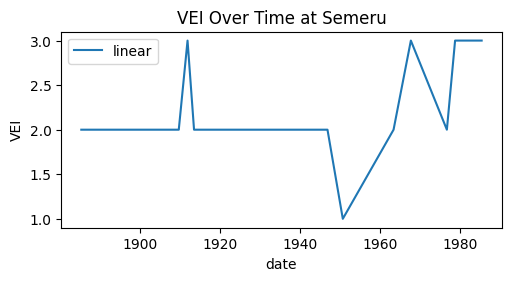

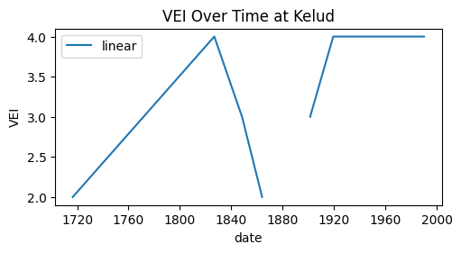

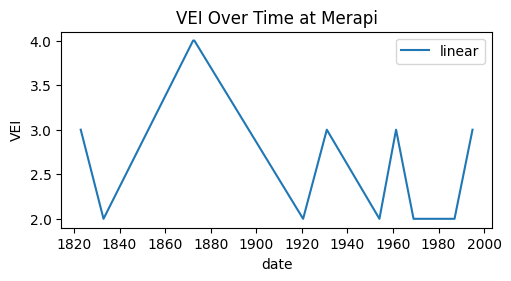

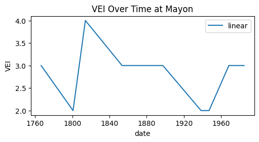

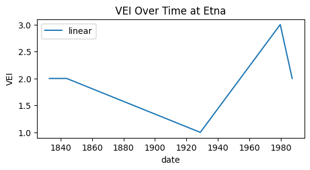

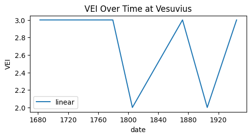

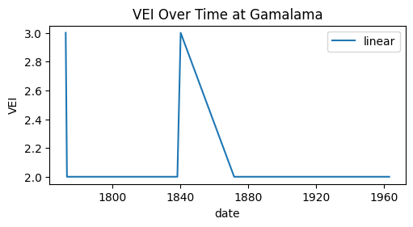

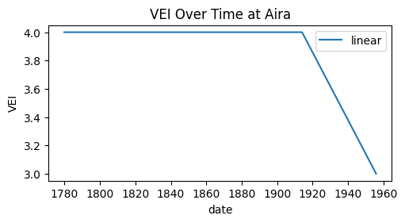

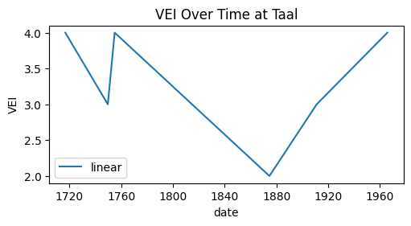

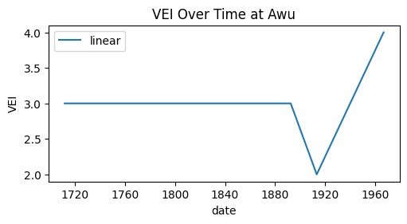

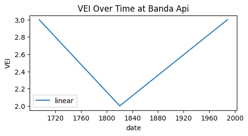

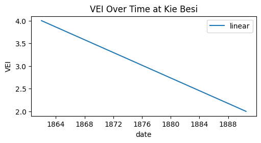

[1 more figures not shown]

```python
# not adding the graphs here, but the graphs should have the volcano name as the title
# the x axis should be the years and the y axis should be the VEI
# A graph that doesn't have these things will only get partial points
import matplotlib.pyplot as plt
import numpy as np

eruption_freq = df['name'].value_counts()
volcanoes = eruption_freq[eruption_freq > 4].index

for volcano in volcanoes:

    new_df = df[df['name'] == volcano].sort_values('date')
    x = new_df['date']
    y = new_df['vei']

    plt.figure(figsize=(5, 2.7), layout='constrained')
    plt.plot(x, y, label='linear')
    plt.xlabel('date')
    plt.ylabel('VEI')
    plt.title(f"VEI Over Time at {volcano}")
    plt.legend()
    plt.show()
```

### **Part 3: City Jobs (15 POINTS TOTAL)**

Proficiency in SQL is also super important. SQL databases are essentially relational databases in which there are vast amounts of tabular data. which can often be used to connect with related tablular data. [This](https://www.w3schools.com/sql/) is a pretty good intro into learning more about SQL.

Check out this [tutorial](https://mode.com/sql-tutorial/introduction-to-sql/) for some clarifications on SQL.

[figure not shown]

**IMPORTANT: Downloading the Dataset**

**Please follow these steps to download the database file:**

- **Step 1:** Go to the Kaggle Dataset
  - Click this link: [SF Salaries Dataset on Kaggle](https://www.kaggle.com/datasets/kaggle/sf-salaries)
- **Step 2:** Create/Login to Kaggle Account
  - You need a free Kaggle account to download datasets
  - If you don't have one, sign up at kaggle.com
  - Log in to your account
- **Step 3:** Download and Extract
  - On the dataset page, click the "Download" button (upper right corner)
  - A ZIP file will be downloaded. Locate it in your system and extract it.
  - You will see a `database.sqlite` file - this is what we need.
  - Move the `database.sqlite` file to the same folder where your notebook is saved.

Now! We'll be using **`sqlite`** to access a database.

- Check out the description of the data so you know the table / column names.

The following code will use `sqlite3` to create a database connection. `sqlite3` is the library in Python that assists in navigating through SQL databases.

**Note:** If you are working on this assignment via Google Colab, sometimes the runtime resets and it will throw errors.

**Instead of running through the entire notebook, run the notebook from the following code block and onwards:**

- Click anywhere on the next code block.
- Go up to where it says **'Runtime'** in the toolbar (right under the title of the notebook and **in between 'Insert' and 'Tools'**)
- Hover over it and **click on the option** that says **'Run cell and below'**

```python
import sqlite3
import pandas as pd # Pandas was already imported from the previous sections

conn = sqlite3.connect("database.sqlite")
crsr = conn.cursor()
```

#### If you cannot see anything when executing this code, that means you did not download the Kaggle dataset correctly.

```python
# This code will let you check out the different tables within the database.
query = "SELECT name FROM sqlite_master WHERE type='table';"
tables = crsr.execute(query).fetchall()
print(tables)
```

```
[('Salaries',), ('Salary_2010',), ('Salary_2011',), ('Salary_2012',), ('Salary_2013',), ('Salary_2014',), ('Salary_2015',), ('Salary in 2010',), ('Salary in 2011',), ('Salary in 2012',), ('Salary in 2013',), ('Salary in 2014',), ('Salary in 2015',)]
```

#### **Remember that each problem should be solved with a single SQL query.**

**Note: All outputs must be shown**

- Only include whatever fields are mentioned throughout each question, nothing more and nothing less.
- Follow each instruction clearly

#### **3.1.1: 2 Points**

From the **Salaries** table, get the **average total pay** for all employees whose job titles contain the word **"clerk" (not case-sensitive)** between the years **2011 to 2014**.

*Remember that any employee with "clerk" in their job title should be included, regardless of other words in the title.*

*Hint: Look into [this](https://www.w3schools.com/mysql/mysql_wildcards.asp)*

```python
query = '''
SELECT AVG(TotalPay)
FROM Salaries
WHERE LOWER(JobTitle) LIKE '%clerk%'
    AND Year BETWEEN 2011 AND 2014
'''

# KEEP THIS. It will display the whole dataframe.
df = pd.read_sql(query, conn)
df
```

|  | AVG(TotalPay) |
| --- | --- |
| 0 | 48086.855056 |

#### **3.1.2: 2 Points**

From the **Salaries** table, get all the clerks (all job titles consisting of the word "clerk" **(not case-sensitive)**) in the **year 2013** making under **$50,000 as a Total pay.** **Sort** them in **descending** order by their pay.

*Remember that clerks that also occupy other professions are still considered clerks.*

```python
query = '''
SELECT *
FROM Salaries
WHERE LOWER(JobTitle) LIKE '%clerk%'
    AND Year = 2013
    AND TotalPay < 50000
ORDER BY TotalPay DESC
'''
# KEEP THIS. It will display the whole dataframe.
df = pd.read_sql(query, conn)
df
```

|  | Id | EmployeeName | JobTitle | BasePay | OvertimePay | OtherPay | Benefits | TotalPay | TotalPayBenefits | Year | Notes | Agency | Status |
| --- | --- | --- | --- | --- | --- | --- | --- | --- | --- | --- | --- | --- | --- |
| 0 | 98430 | Linda A Sabau | Senior Clerk | 47570.1 | 275.31 | 2103.83 | 25454.96 | 49949.24 | 75404.20 | 2013 |  | San Francisco |  |
| 1 | 98651 | Laurie A Kassel | Clerk | 49316.45 | 0.00 | 606.66 | 24224.17 | 49923.11 | 74147.28 | 2013 |  | San Francisco |  |
| 2 | 98437 | Roberto O Ayala-Duran | Assessment Clerk | 48735.83 | 101.76 | 1080.00 | 25450.56 | 49917.59 | 75368.15 | 2013 |  | San Francisco |  |
| 3 | 98994 | Norma C Morales | Clerk Typist | 48206.65 | 665.44 | 985.00 | 21798.61 | 49857.09 | 71655.70 | 2013 |  | San Francisco |  |
| 4 | 98971 | Candice Y Ye | Senior Account Clerk | 49831.41 | 0.00 | 0.00 | 21964.08 | 49831.41 | 71795.49 | 2013 |  | San Francisco |  |
| 5 | 98486 | Giles Samarasinghe | Senior Clerk | 49075.23 | 670.92 | 0.00 | 25324.38 | 49746.15 | 75070.53 | 2013 |  | San Francisco |  |
| 6 | 98552 | Naimah J Crum | Senior Clerk | 46911.8 | 0.00 | 2819.48 | 24943.68 | 49731.28 | 74674.96 | 2013 |  | San Francisco |  |
| 7 | 99563 | Amado A Lumas Jr | Account Clerk | 38644.51 | 0.00 | 11032.90 | 16975.13 | 49677.41 | 66652.54 | 2013 |  | San Francisco |  |
| 8 | 99677 | Erlinda A Mapote | Senior Clerk Typist | 37842.05 | 0.00 | 11658.00 | 15813.60 | 49500.05 | 65313.65 | 2013 |  | San Francisco |  |
| 9 | 98769 | William K Ho | Clerk | 48848.16 | 0.00 | 600.89 | 23847.37 | 49449.05 | 73296.42 | 2013 |  | San Francisco |  |
| 10 | 98523 | Edward W Wang | Account Clerk | 49446.02 | 0.00 | 0.00 | 25410.61 | 49446.02 | 74856.63 | 2013 |  | San Francisco |  |
| 11 | 98667 | Rockson C Yan | Account Clerk | 47667.18 | 1712.95 | 0.00 | 24670.19 | 49380.13 | 74050.32 | 2013 |  | San Francisco |  |
| 12 | 98592 | Vanessa O Basco | Medical Records Clerk | 48485 | 834.98 | 0.00 | 25119.62 | 49319.98 | 74439.60 | 2013 |  | San Francisco |  |
| 13 | 99664 | Angelica J Young | Deputy Court Clerk III | 45800.5 | 0.00 | 3500.00 | 16154.19 | 49300.50 | 65454.69 | 2013 |  | San Francisco |  |
| 14 | 98589 | Jefferyi G Baquiran | Senior Clerk | 48247.42 | 1047.81 | 0.00 | 25176.55 | 49295.23 | 74471.78 | 2013 |  | San Francisco |  |
| 15 | 98572 | Susan A Boucher | Senior Clerk | 48854.3 | 437.49 | 0.00 | 25281.70 | 49291.79 | 74573.49 | 2013 |  | San Francisco |  |
| 16 | 99149 | Elizabeth A Cano | Senior Clerk Typist | 49289.84 | 0.00 | 0.00 | 20980.33 | 49289.84 | 70270.17 | 2013 |  | San Francisco |  |
| 17 | 99005 | Suzanne S Mai | Account Clerk | 49275.03 | 0.00 | 0.00 | 22291.92 | 49275.03 | 71566.95 | 2013 |  | San Francisco |  |
| 18 | 99032 | Gwendolyn Y Wade | Senior Clerk | 49261.28 | 0.00 | 0.00 | 22100.21 | 49261.28 | 71361.49 | 2013 |  | San Francisco |  |
| 19 | 98575 | Christian N Velasquez | Senior Clerk | 49205.71 | 0.00 | 0.00 | 25346.75 | 49205.71 | 74552.46 | 2013 |  | San Francisco |  |
| 20 | 98618 | Lien Lum | Account Clerk | 49198.51 | 0.00 | 0.00 | 25090.96 | 49198.51 | 74289.47 | 2013 |  | San Francisco |  |
| 21 | 98583 | Lilibelle I L Thompson | Senior Clerk | 49153.54 | 0.00 | 0.00 | 25333.95 | 49153.54 | 74487.49 | 2013 |  | San Francisco |  |
| 22 | 99849 | Erlinda Andres | Health Care Billing Clerk 2 | 37279.51 | 0.00 | 11803.64 | 14273.54 | 49083.15 | 63356.69 | 2013 |  | San Francisco |  |
| 23 | 98602 | Christopher I Victorio | Senior Clerk | 49075.22 | 0.00 | 0.00 | 25317.67 | 49075.22 | 74392.89 | 2013 |  | San Francisco |  |
| 24 | 98709 | Enrico C Intal | Junior Clerk | 48357 | 0.00 | 648.00 | 24798.99 | 49005.00 | 73803.99 | 2013 |  | San Francisco |  |
| 25 | 98710 | Eddy J Redondo | Junior Clerk | 48357 | 0.00 | 647.70 | 24798.92 | 49004.70 | 73803.62 | 2013 |  | San Francisco |  |
| 26 | 98625 | Petra O Brady | Senior Clerk | 49000.96 | 0.00 | 0.00 | 25257.50 | 49000.96 | 74258.46 | 2013 |  | San Francisco |  |
| 27 | 98629 | Adriana M Ortiz | Senior Clerk | 48949.01 | 0.00 | 0.00 | 25290.49 | 48949.01 | 74239.50 | 2013 |  | San Francisco |  |
| 28 | 98639 | Jacqueline F Davis | Senior Clerk | 48744.61 | 0.00 | 200.00 | 25246.41 | 48944.61 | 74191.02 | 2013 |  | San Francisco |  |
| 29 | 99050 | Rita H Tam | Senior Clerk | 48649.88 | 0.00 | 240.00 | 22285.14 | 48889.88 | 71175.02 | 2013 |  | San Francisco |  |

[output cut: 757 more lines]

#### **3.1.3: 4 Points**

From the **Salaries** table, first get the **averages** of **base pay**, **benefits**, and **overtime pay** for clerks (all job titles consisting of the word "clerk" **(not case-sensitive)**).

- Then, make a **column with the sum** of these **three averages**
- Finally, **exclude** job titles containing "SENIOR" **(case-sensitive)**

*Remember that clerks that also occupy other professions are still considered clerks.*

**Example:**

Let's say the Salaries table has these records:

| JobTitle | BasePay | Benefits | OvertimePay |
| --- | --- | --- | --- |
| CLERK | 40000 | 15000 | 5000 |
| Clerk | 35000 | 12000 | 3000 |
| ACCOUNTING CLERK | 45000 | 18000 | 6000 |
| SENIOR CLERK | 60000 | 25000 | 8000 |
| Senior Clerk | 55000 | 22000 | 7000 |
| MANAGER | 80000 | 30000 | 10000 |

**Which rows to include:**

- Rows 1, 2, 3, 5 (all contain "clerk" in any case)
- Exclude Row 4 (contains uppercase "SENIOR")
- Exclude Row 6 (doesn't contain "clerk")

**Calculate averages from rows 1, 2, 3, 5:**

- avg_base_pay = (40000 + 35000 + 45000 + 55000) / 4 = 43750
- avg_benefits = (15000 + 12000 + 18000 + 22000) / 4 = 16750
- avg_overtime_pay = (5000 + 3000 + 6000 + 7000) / 4 = 5250
- total_avg_compensation = 43750 + 16750 + 5250 = 65750

**Your output:**

| avg_base_pay | avg_benefits | avg_overtime_pay | total_avg_compensation |
| --- | --- | --- | --- |
| 43750 | 16750 | 5250 | 65750 |

*Note: Actual values from the database will be different!*

```python
query = '''
SELECT
    AVG(BasePay) AS avg_base_pay,
    AVG(Benefits) AS avg_benefits,
    AVG(OvertimePay) AS avg_overtime_pay,
    AVG(BasePay) + AVG(Benefits) + AVG(OvertimePay) AS total_avg_compensation
FROM Salaries
WHERE Lower(JobTitle) LIKE '%clerk%'
    AND JobTitle NOT GLOB '%SENIOR%'

'''

# KEEP THIS. It will display the whole dataframe.
df = pd.read_sql(query, conn)
df
```

|  | avg_base_pay | avg_benefits | avg_overtime_pay | total_avg_compensation |
| --- | --- | --- | --- | --- |
| 0 | 46325.027282 | 15632.276656 | 926.97962 | 62884.283558 |